# Ana_Fernandes_M5_HW

Author

AGF

# Setup

```r
# limpa todos os objetos, incluindo os ocultos
rm(list = ls(all.names = TRUE))

#definir seed
set.seed(123)

# Packages
required_packages <- c(
                       "assertr",
                       "cardx",
                       "data.validator",
                       "dplyr",
                       "officer",
                       "janitor",
                       "tidyverse",
                       "rio",
                       "data.table",
                       "broom",
                       "gt",
                       "gtsummary",
                       "glm2",
                       "performance",
                       "see"
                       # colocar aqui se foram utilizados mais pacotes
                       )

for (pkg in required_packages) {
  # install packages if not already present
  if (!pkg %in% rownames(installed.packages())) {
    install.packages(pkg)
  }

  # load packages to this current session
  library(pkg, character.only = TRUE)
}
remove(required_packages)
remove(pkg)
```

# Exercício - Hipotermia Cirúrgica

## Contexto

A hipotermia cirúrgica (definida como temperatura central < 36°C) é conhecida por causar coagulopatia, alteração no metabolismo de drogas, recuperação prolongada e desconforto térmico. Menos compreendido é se as infecções do sítio cirúrgico (ISCs) também estão associadas à hipotermia intraoperatória.

Isso é importante, pois as infecções do sítio cirúrgico (ISC) são uma grande fonte de morbidade, mortalidade, prolongamento da hospitalização e custos de saúde. O risco geral de ISC é de 1 a 3%, geralmente, mas é substancialmente maior, 10 a 15%, para pacientes submetidos à cirurgia colorretal.

Literatura publicada até a data sugere que a hipotermia moderada causa ISCs e várias outras complicações. No entanto, alguns desses estudos estão desatualizados (os procedimentos cirúrgicos descritos já não são realizados) e muitos não possuem dados suficientes de temperatura intraoperatória. Portanto, é desconhecido se a hipotermia leve ou temperaturas normotérmicas influenciam o risco de infecção. [^1]

## Objetivo

Avaliar a relação entre a média ponderada do tempo (TWATemp) da temperatura central e as infecções graves de feridas e sistêmicas que se desenvolvem dentro de 30 dias após a cirurgia colorretal, no geral e após levar em conta as informações de covariáveis.

## Instruções

### Dataset

Use o dataset Core_Temperature.xlsx, e consulte a documentação em Core_Temperature_Data_Dictionary2.pdf na pasta de datasets. O objetivo geral do exercício é avaliar o efeito da temperatura (TWATemp) no risco de ISCs (AnyInfection).

1. Importar para um objeto “temperature_data” com o dataset

```r
library(readxl)
Core_Temperature <- read_excel("datasets/Core_Temperature.xlsx")
View(Core_Temperature)
```

```r
# Vamos inspecionar o conjunto de dados
head(Core_Temperature)
```

```
# A tibble: 6 × 47
   YEAR   Age FEMALE   BMI CharlsonScore SurgeryType    CHF VALVE    DM RENLFAIL
  <dbl> <dbl>  <dbl> <dbl>         <dbl> <chr>        <dbl> <dbl> <dbl>    <dbl>
1  2009  63.7      0  39.3             2 "colostomy …     0     0     0        0
2  2009  58.7      0  25.3             3 "ileostomy"      0     0     1        0
3  2009  84.6      0  31.6             1 "colostomy …     0     0     1        0
4  2009  35.1      1  25.5             0 "ileostomy"      0     1     0        0
5  2009  49.3      0  22.2             6 "ileostomy"      0     0     0        0
6  2009  62.9      0  33               0 "ileostomy"      0     0     0        0
# ℹ 37 more variables: LIVER <dbl>, METS <dbl>, TUMOR <dbl>, COAG <dbl>,
#   OBESE <dbl>, WGHTLOSS <dbl>, LYTES <dbl>, BLDLOSS <dbl>, ANEMDEF <dbl>,
#   DRUG <dbl>, SteroidHx <dbl>, ImmunosuppressantHx <dbl>, SurgDuration <dbl>,
#   Open <dbl>, AbsessIntraAb <dbl>, AbsessPelvic <dbl>, Cdiff <dbl>,
#   FascialDehiscence <dbl>, DelayedHealing <dbl>, Infection <dbl>,
#   Sinus <dbl>, Pneumonia <dbl>, `Pneumonia(aspiration)` <dbl>, Sepsis <dbl>,
#   `SSIDeep(fascia)` <dbl>, SSIOrganSpace <dbl>, …
```

```r
#dar um novo nome ao DF apos limpar as variaveis
temperatura_data <- Core_Temperature
```

2. Limpar o nome das variáveis

```r
# Limpar nomes
# Este comando garante que todos os nomes das variáveis estão em minúsculas e sem espaços
temperatura_data <- clean_names(Core_Temperature)

colnames(temperatura_data) # ver nomes alterados
```

```
 [1] "year"                  "age"                   "female"
 [4] "bmi"                   "charlson_score"        "surgery_type"
 [7] "chf"                   "valve"                 "dm"
[10] "renlfail"              "liver"                 "mets"
[13] "tumor"                 "coag"                  "obese"
[16] "wghtloss"              "lytes"                 "bldloss"
[19] "anemdef"               "drug"                  "steroid_hx"
[22] "immunosuppressant_hx"  "surg_duration"         "open"
[25] "absess_intra_ab"       "absess_pelvic"         "cdiff"
[28] "fascial_dehiscence"    "delayed_healing"       "infection"
[31] "sinus"                 "pneumonia"             "pneumonia_aspiration"
[34] "sepsis"                "ssi_deep_fascia"       "ssi_organ_space"
[37] "ssi_superficial_skin"  "wound_infection"       "twa_temp"
[40] "last_reading_temp"     "end_case_temp"         "any_infection"
[43] "serious_infection"     "superficial_infection" "duration_hosp"
[46] "los"                   "dead"
```

```r
View(temperatura_data)
```

### Exercicio M5.1 Estatística Descritiva

Deve criar uma Tabela 1 comparando a distribuição das variáveis de confundimento (Age, FEMALE, BMI, CharlsonScore, SurgeryType, CHF) pelos pacientes que tiveram ISC (AnyInfection).

Nota: variável de confusão: é uma variável que influencia tanto a variável dependente, quanto a variável independente.

1. O nome do objeto deve ser table 1

```r
# carregar pacote exigido para a criação da tabela
install.packages("cardx")
library(cardx)
```

```r
#atribuir valor ao 0 e 1 de any_infection
temperatura_data <- temperatura_data %>%
  mutate(any_infection_yn = case_when(
    any_infection == 0 ~ "No",
    any_infection == 1 ~ "Yes",
    TRUE ~ as_label(any_infection) # alterei para label por causa do aviso -> Warning: Using `as.character()` on a quosure is deprecated as of rlang 0.3.0. Please use `as_label()` or `as_name()` instead.
  ))

head(temperatura_data)
```

```
# A tibble: 6 × 48
   year   age female   bmi charlson_score surgery_type           chf valve    dm
  <dbl> <dbl>  <dbl> <dbl>          <dbl> <chr>                <dbl> <dbl> <dbl>
1  2009  63.7      0  39.3              2 "colostomy or color…     0     0     0
2  2009  58.7      0  25.3              3 "ileostomy"              0     0     1
3  2009  84.6      0  31.6              1 "colostomy or color…     0     0     1
4  2009  35.1      1  25.5              0 "ileostomy"              0     1     0
5  2009  49.3      0  22.2              6 "ileostomy"              0     0     0
6  2009  62.9      0  33                0 "ileostomy"              0     0     0
# ℹ 39 more variables: renlfail <dbl>, liver <dbl>, mets <dbl>, tumor <dbl>,
#   coag <dbl>, obese <dbl>, wghtloss <dbl>, lytes <dbl>, bldloss <dbl>,
#   anemdef <dbl>, drug <dbl>, steroid_hx <dbl>, immunosuppressant_hx <dbl>,
#   surg_duration <dbl>, open <dbl>, absess_intra_ab <dbl>,
#   absess_pelvic <dbl>, cdiff <dbl>, fascial_dehiscence <dbl>,
#   delayed_healing <dbl>, infection <dbl>, sinus <dbl>, pneumonia <dbl>,
#   pneumonia_aspiration <dbl>, sepsis <dbl>, ssi_deep_fascia <dbl>, …
```

```r
# #chat
# # Verificar o tipo da coluna
# str(temperatura_data$surgery_type)
#
# # Corrigir a coluna para fator ou caractere
# temperatura_data <- temperatura_data %>%
#   mutate(surgery_type = as.factor(surgery_type))  # Converter surgery_type para fator
#
# # Usar fct_explicit_na para tratar NA como "Unknown"
# temperatura_data <- temperatura_data %>%
#   mutate(surgery_type = fct_explicit_na(surgery_type, na_level = "Unknown"))
#
# # Criar a tabela
# tabela1 <- temperatura_data %>%
#   select(age, female, bmi, charlson_score, surgery_type, chf, any_infection_yn) %>%
#   tbl_summary(
#     missing = "ifany",
#     missing_text = "Unknown",
#     by = any_infection_yn,
#     label = list(
#       age ~ "Idade",
#       female ~ "Sexo Feminino",
#       bmi ~ "Índice de Massa Corporal (BMI)",
#       charlson_score ~ "Índice de Charlson",
#       surgery_type ~ "Tipo de Cirurgia",
#       chf ~ "Insuficiência Cardíaca Congestiva"
#     ),
#     statistic = list(all_continuous() ~ "{mean} ({sd})",
#                      all_categorical() ~ "{n} ({p}%)")
#   ) %>%
#   add_p()
#
# tabela1
```

```r
#chat2
# Criar a tabela sem o fct_explicit_na
tabela1 <- temperatura_data %>%
  select(age, female, bmi, charlson_score, surgery_type, chf, any_infection_yn) %>%
  tbl_summary(
    missing = "no",
    by = any_infection_yn,
    label = list(
      age ~ "Idade",
      female ~ "Sexo Feminino",
      bmi ~ "Índice de Massa Corporal (BMI)",
      charlson_score ~ "Índice de Charlson",
      surgery_type ~ "Tipo de Cirurgia",
      chf ~ "Insuficiência Cardíaca Congestiva"
    ),
    statistic = list(all_continuous() ~ "{mean} ({sd})",
                     all_categorical() ~ "{n} ({p}%)")
  ) %>%
  add_p()|> # Tornar as etiquetas em negrito para ênfase
  as_gt()

# Exibir a tabela
tabela1
```

| **Characteristic** | **No** N = 6,780<sup>1</sup> | **Yes** N = 1,128<sup>1</sup> | **p-value**<sup>2</sup> |
| --- | --- | --- | --- |
| Idade | 56 (17) | 56 (16) | 0.8 |
| Sexo Feminino | 3,450 (51%) | 552 (49%) | 0.2 |
| Índice de Massa Corporal (BMI) | 26.4 (6.1) | 27.4 (6.8) | <0.001 |
| Índice de Charlson | 1.42 (2.04) | 1.57 (2.22) | 0.076 |
| Tipo de Cirurgia |  |  | 0.8 |
| colostomy or colorectal resection | 2,753 (41%) | 472 (42%) |  |
| ileostomy | 2,834 (42%) | 453 (40%) |  |
| lysis of adhesions | 169 (2.5%) | 31 (2.7%) |  |
| other procedures | 14 (0.2%) | 2 (0.2%) |  |
| small bowel resection and other enterostomy | 1,010 (15%) | 170 (15%) |  |
| Insuficiência Cardíaca Congestiva | 219 (3.2%) | 55 (4.9%) | 0.005 |

<sup>1</sup> Mean (SD); n (%)  
<sup>2</sup> Wilcoxon rank sum test; Pearson’s Chi-squared test; Fisher’s exact test

```r
# # criar uma tabela, chamada tabela 1
# tabela1 <- temperatura_data %>%
#   select(age, female, bmi, charlson_score, surgery_type, chf, any_infection_yn) %>%  # Selecionar variáveis de interesse
#   tbl_summary(
#     missing = "ifany",        # Argumento que indica como tratar missing
#     missing_text = "Unknown",  # Texto para valores em falta
#     by = any_infection_yn,  # Comparar os grupos com e sem infecção
#     label = list(
#       age ~ "Idade",
#       female ~ "Sexo Feminino",
#       bmi ~ "Índice de Massa Corporal (BMI)",
#       charlson_score ~ "Índice de Charlson",
#       surgery_type ~ "Tipo de Cirurgia",
#       chf ~ "Insuficiência Cardíaca Congestiva"
#     ),
#     statistic = list(all_continuous() ~ "{mean} ({sd})",  # Média e desvio padrão para variáveis contínuas
#                      all_categorical() ~ "{n} ({p}%)")  # Frequências para variáveis categóricas
#   ) %>%
#   add_p()  # Adicionar testes estatísticos de comparação entre os grupos
#
# tabela1
```

### Exercicio M5.2 Visualização

Deve criar uma visualização comparando a distribuição da temperatura (TWATemp) pelo risco de ISCs (AnyInfection).

1. Visualização deve ser criada no objeto p1

```r
# instalar pacote requerido
library(ggplot2)
```

```r
# Serve para controlar o tamanho das figuras geradas dentro do documento. Estes valores definem a altura e a largura dos gráficos ou imagens quando são renderizados no relatório final.
#| fig-height: 5
#| fig-width: 7.5
```

### Gráfico em Boxplot

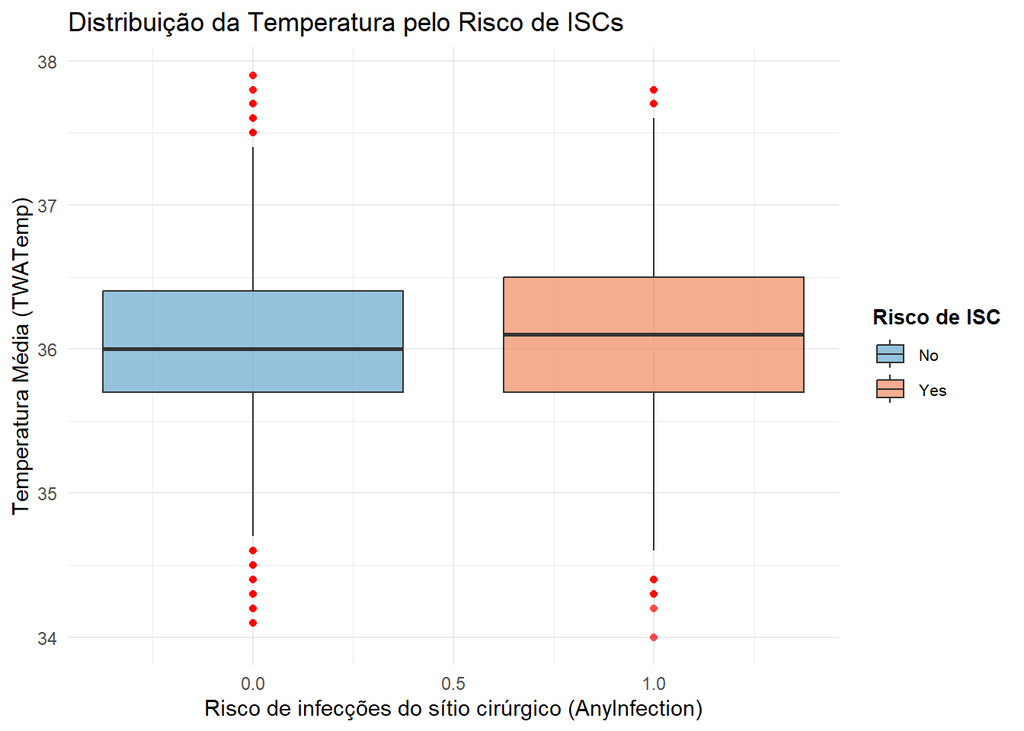

```r
# Criar o gráfico de boxplot para comparar a distribuição de temperatura (TWATemp) por AnyInfection
p1 <- ggplot(temperatura_data, aes(x = any_infection, y = twa_temp, fill = any_infection_yn)) +
  geom_boxplot(alpha = 0.7, outlier.color = "red", outlier.shape = 16) +
  scale_fill_manual(values = c("Yes" = "#ef8a62", "No" = "#67a9cf")) +  # Definindo as cores
  labs(
    title = "Distribuição da Temperatura pelo Risco de ISCs",
    x = "Risco de infecções do sítio cirúrgico (AnyInfection)",
    y = "Temperatura Média (TWATemp)",
    fill = "Risco de ISC"
  ) +
  theme_minimal() +
  theme(
    legend.position = "right",             # Colocar a legenda à direita
    legend.title = element_text(size = 10, face = "bold"),  # Título da legenda
    legend.text = element_text(size = 8) )  # Texto da legenda

p1
```

### Gráfico em Violino

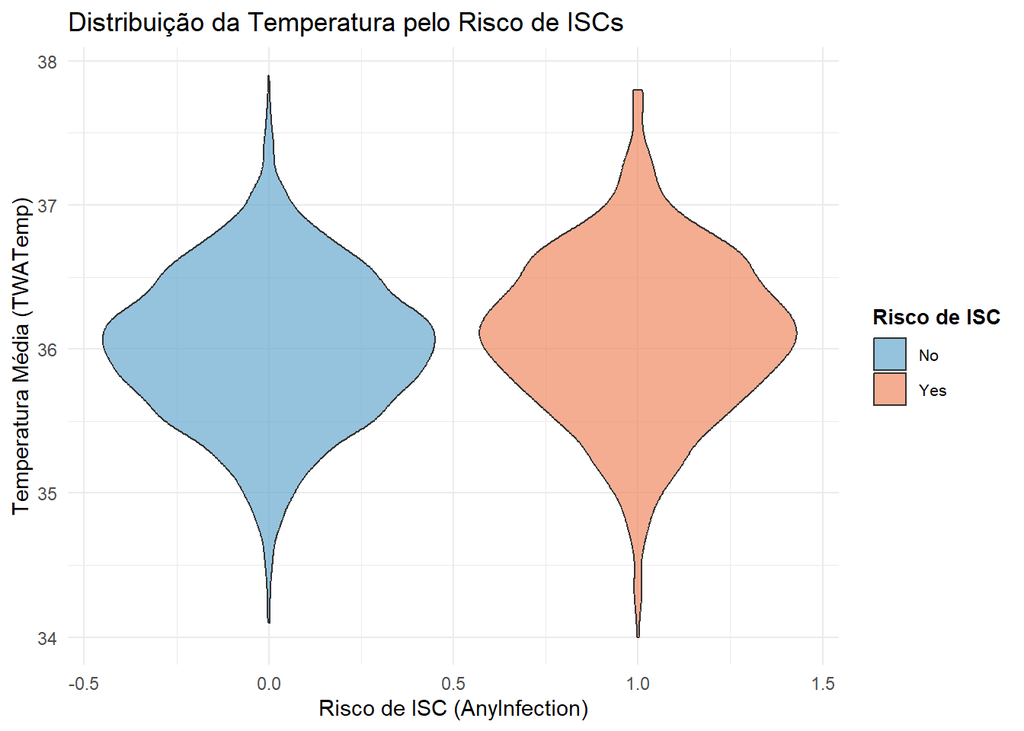

```r
p2 <- ggplot(temperatura_data, aes(x = any_infection, y = twa_temp, fill = any_infection_yn)) +
  geom_violin(alpha = 0.7) +
  scale_fill_manual(values = c("Yes" = "#ef8a62", "No" = "#67a9cf")) +  # Definindo as cores
  labs(
    title = "Distribuição da Temperatura pelo Risco de ISCs",
    x = "Risco de ISC (AnyInfection)",
    y = "Temperatura Média (TWATemp)",
    fill = "Risco de ISC"  # Título da legenda
  ) +
  theme_minimal() +
  theme(
    legend.position = "right",             # Colocar a legenda à direita
    legend.title = element_text(size = 10, face = "bold"),  # Título da legenda
    legend.text = element_text(size = 8) )  # Texto da legenda
p2
```

### Exercicio M5.3 Modelos

#### Exercicio M5.3.1 Univariado

Crie um modelo de regressão logística para avaliar o efeito da temperatura no risco de ISCs (AnyInfection).

1. Criar modelo no objeto model_logit_uni

```r
# Criar o modelo de regressão logística
model_logit_uni <- glm(any_infection ~ twa_temp,
                       data = temperatura_data,
                       family = binomial())

# Resumo do modelo para ver os resultados
summary(model_logit_uni)
```

```
Call:
glm(formula = any_infection ~ twa_temp, family = binomial(),
    data = temperatura_data)

Deviance Residuals:
    Min       1Q   Median       3Q      Max
-0.7002  -0.5728  -0.5441  -0.5100   2.2146

Coefficients:
             Estimate Std. Error z value Pr(>|z|)
(Intercept) -11.78845    2.21431  -5.324 1.02e-07 ***
twa_temp      0.27724    0.06137   4.518 6.25e-06 ***
---
Signif. codes:  0 '***' 0.001 '**' 0.01 '*' 0.05 '.' 0.1 ' ' 1

(Dispersion parameter for binomial family taken to be 1)

    Null deviance: 6480.3  on 7907  degrees of freedom
Residual deviance: 6459.7  on 7906  degrees of freedom
AIC: 6463.7

Number of Fisher Scoring iterations: 4
```

2. Criar tabela com dados da regressão no objeto model_logit_uni_tidy

```r
# Criar a tabela com os dados da regressão
model_logit_uni_tidy <- broom::tidy(model_logit_uni)

# broom::tidy(model_logit_uni): Usa a função tidy() para criar um data frame com os resultados da regressão logística. Este data frame incluirá informações como os coeficientes, erros padrão, valores z, e valores p dos parâmetros do modelo.

# Visualizar a tabela
print(model_logit_uni_tidy)
```

```
# A tibble: 2 × 5
  term        estimate std.error statistic     p.value
  <chr>          <dbl>     <dbl>     <dbl>       <dbl>
1 (Intercept)  -11.8      2.21       -5.32 0.000000102
2 twa_temp       0.277    0.0614      4.52 0.00000625
```

```r
#O resultado será uma tabela com colunas típicas, como:

# term: Os nomes dos termos (intercepto e variáveis independentes).
# estimate: Os coeficientes estimados.
# std.error: Os erros padrão dos coeficientes.
# statistic: Os valores z (ou estatísticas de teste).
# p.value: Os valores p associados a cada termo.
```

#### Exercicio M5.3.2 Múltiplo

Crie um modelo de regressão logística para avaliar o efeito da temperatura no risco de ISCs (AnyInfection) ajustado para Age, FEMALE, BMI, CharlsonScore e CHF.

1. Criar modelo no objeto model_logit_multi

Esclarecimento: 1.1 Charlson Score: O Índice de Comorbidade de Charlson é definido como uma pontuação composta ponderada que prevê a mortalidade em 1 ano com base na presença de várias condições coexistentes, como doenças cardiovasculares, endócrinas, pulmonares, neurológicas, renais, hepáticas, gastrointestinais e neoplásicas. 1.2 CHF: Congestive heart failure - Insuficiência Cardíaca Congestiva

```r
# Criar um modelo de regressão logística para prever a ocorrência de risco de ISCs (AnyInfection).
# Criar o modelo de regressão logística
model_logit_multi <- glm(any_infection ~ twa_temp + age + female +bmi + charlson_score + chf,
                        data = temperatura_data,
                        family = binomial)

# glm(): Esta função é usada para ajustar o modelo de regressão. Aqui, AnyInfection é a variável dependente (resposta), enquanto TWATemp, Age, FEMALE, BMI, CharlsonScore e CHF são as variáveis independentes (preditoras). A família binomial indica que se trata de uma regressão logística.
# data = temperatura_data: Especifica o conjunto de dados que contém as variáveis.
# summary(model_logit_uni): Esta linha gera um resumo do modelo ajustado, incluindo os coeficientes, erros padrão, valores z e p.
# broom::tidy(model_logit_uni): Converte os resultados do modelo em um formato de tabela (data frame) para facilitar a visualização e interpretação dos resultados.

# Resumo do modelo
summary(model_logit_multi)
```

```
Call:
glm(formula = any_infection ~ twa_temp + age + female + bmi +
    charlson_score + chf, family = binomial, data = temperatura_data)

Deviance Residuals:
    Min       1Q   Median       3Q      Max
-0.9889  -0.5743  -0.5342  -0.4910   2.2537

Coefficients:
                 Estimate Std. Error z value Pr(>|z|)
(Intercept)    -10.799188   2.282098  -4.732 2.22e-06 ***
twa_temp         0.237536   0.063039   3.768 0.000165 ***
age             -0.002730   0.002172  -1.257 0.208642
female          -0.057248   0.064845  -0.883 0.377319
bmi              0.021274   0.005009   4.247 2.17e-05 ***
charlson_score   0.024501   0.017258   1.420 0.155702
chf              0.341908   0.166209   2.057 0.039677 *
---
Signif. codes:  0 '***' 0.001 '**' 0.01 '*' 0.05 '.' 0.1 ' ' 1

(Dispersion parameter for binomial family taken to be 1)

    Null deviance: 6480.3  on 7907  degrees of freedom
Residual deviance: 6431.1  on 7901  degrees of freedom
AIC: 6445.1

Number of Fisher Scoring iterations: 4
```

2. Criar tabela com dados da regressão no objeto model_logit_multi_tidy

```r
# Criar uma tabela tidy com os resultados do modelo
model_logit_multi_tidy <- broom::tidy(model_logit_multi)

# Visualizar a tabela
print(model_logit_multi_tidy)
```

```
# A tibble: 7 × 5
  term            estimate std.error statistic    p.value
  <chr>              <dbl>     <dbl>     <dbl>      <dbl>
1 (Intercept)    -10.8       2.28       -4.73  0.00000222
2 twa_temp         0.238     0.0630      3.77  0.000165
3 age             -0.00273   0.00217    -1.26  0.209
4 female          -0.0572    0.0648     -0.883 0.377
5 bmi              0.0213    0.00501     4.25  0.0000217
6 charlson_score   0.0245    0.0173      1.42  0.156
7 chf              0.342     0.166       2.06  0.0397
```

#### Exercicio M5.3.3 Performance

Compare os dois modelos em termos de performance.

```r
# Ajustando modelos
model_logit_uni <- glm(any_infection ~ twa_temp, data = temperatura_data, family = binomial)
model_logit_multi <- glm(any_infection ~ twa_temp + age +female + bmi + charlson_score + chf, data = temperatura_data, family = binomial)

# Comparando desempenho dos modelos

comparison <- compare_performance(model_logit_uni, model_logit_multi)

# Exibindo a comparação
print(comparison)
```

```
# Comparison of Model Performance Indices

Name              | Model |  AIC (weights) | AICc (weights) |  BIC (weights) | Tjur's R2 |  RMSE | Sigma | Log_loss | Score_log | Score_spherical |   PCP
---------------------------------------------------------------------------------------------------------------------------------------------------------
model_logit_uni   |   glm | 6463.7 (<.001) | 6463.7 (<.001) | 6477.7 (>.999) |     0.003 | 0.349 | 0.904 |    0.408 |  -173.094 |       1.273e-04 | 0.756
model_logit_multi |   glm | 6445.1 (>.999) | 6445.1 (>.999) | 6494.0 (<.001) |     0.006 | 0.349 | 0.902 |    0.407 |  -173.472 |       1.445e-04 | 0.757
```

A tabela resume as métricas de desempenho dos dois modelos de regressão logística que você ajustou: **model_logit_uni** (modelo univariado) e **model_logit_multi** (modelo multivariado). Vamos interpretar cada uma das métricas apresentadas:

### 1. AIC (Akaike Information Criterion) e AICc

**AIC**: O AIC é uma medida da qualidade do modelo que penaliza a complexidade do modelo (número de parâmetros). Valores mais baixos de AIC indicam um melhor ajuste. A comparação é feita em relação a outros modelos: o modelo com o menor AIC é considerado o melhor. **AICc**: É uma versão corrigida do AIC que ajusta para tamanhos de amostra pequenos. Assim como o AIC, valores mais baixos são melhores. Interpretação dos pesos: O valor entre parênteses indica a probabilidade relativa de que o modelo seja o melhor dentre os modelos comparados, dado o conjunto de dados. Valores próximos de 1 (ou >0.999) indicam que o modelo é altamente preferido. Por exemplo, para **model_logit_multi**, a AIC e AICc são praticamente equivalentes e têm um peso acima de 0.999, o que sugere que este modelo é preferido em relação ao modelo univariado (**model_logit_uni**).

### 2. BIC (Bayesian Information Criterion)

**BIC**: Assim como o AIC, o BIC penaliza a complexidade do modelo, mas aplica uma penalidade mais severa ao número de parâmetros do que o AIC. Valores mais baixos são melhores. Interpretação: Aqui, **model_logit_uni** tem um BIC menor, indicando que, de acordo com essa métrica, ele pode ser preferido. O peso (>.999) para **model_logit_uni** sugere uma alta probabilidade de que este modelo seja o melhor em termos de BIC, enquanto o modelo multivariado apresenta um valor maior.

### 3. Tjur’s R²

**Tjur’s R²**: É uma medida de eficácia do modelo que indica a proporção da variação da resposta que é explicada pelo modelo. Valores próximos de 1 indicam que o modelo explica bem os dados, enquanto valores próximos de 0 indicam o contrário. Interpretação: Ambos os modelos têm valores muito baixos (próximos de 0), sugerindo que eles não explicam bem a variação nos dados. O **model_logit_multi** apresenta um Tjur’s R² um pouco maior (0.006 em comparação com 0.003), indicando que o modelo multivariado tem um desempenho ligeiramente melhor nesse aspecto.

### 4. RMSE (Root Mean Square Error)

**RMSE**: Medida de erro que representa a média dos resíduos ao quadrado. Um RMSE menor indica um modelo com um melhor ajuste. Interpretação: Ambos os modelos têm o mesmo RMSE (0.349), o que significa que não há diferença em termos de erro entre os dois modelos.

### 6. Log_loss

**Log_loss**: Mede a performance de um modelo de classificação ao quantificar a incerteza nas previsões. Valores menores indicam melhor performance. Interpretação: O **model_logit_multi** tem um log_loss um pouco menor que o **model_logit_uni**, sugerindo que ele tem um desempenho ligeiramente melhor em termos de previsões.

### 7. Score_log e Score_spherical

**Score_log**: Refere-se à log-verossimilhança do modelo. Um valor mais alto indica melhor ajuste do modelo aos dados. **Score_spherical**: Refere-se a uma medida alternativa de ajuste. Interpretação: O modelo univariado apresenta um score_log de -173.094, enquanto o multivariado tem -173.472. Isso sugere que o modelo univariado tem um ajuste ligeiramente melhor segundo essa métrica.

### 8. PCP (Proporção de Concordância da Predição)

**PCP**: É uma métrica que mede a proporção de predições corretas do modelo. Valores mais altos indicam melhor desempenho. Interpretação: O **model_logit_multi** tem uma PCP de 0.757, que é um pouco mais alta em comparação com 0.756 do modelo univariado, indicando que o modelo multivariado faz previsões ligeiramente melhores.

### Exercicio M5.4 Tabelas de Regressão

Crie uma tabela com os OR (Odds Ratios), p-value e Confidence Intervals do modelo model_logit_multi construído em 5.3.2.

1. O objeto tabela deve-se chamar tbl_multi

```r
# Transformar os resultados do modelo em um formato tabular (com o pacote broom por exemplo), e depois aplicar o gt().
# Extrair resultados do modelo logístico com tidy() do broom
model_logit_multi_tidy <- tidy(model_logit_multi, exponentiate = TRUE, conf.int = TRUE)
```

```r
# Criar uma tabela com o pacote gt a partir do resumo do modelo 'model_logit_multi'

# Criar a tabela gt com os coeficientes, OR, p-value e IC
tbl_multi <- model_logit_multi_tidy %>%
  gt() %>%
  tab_header(
    title = md("**Modelo do efeito da temperatura no risco de ISCs**"),
    subtitle = "Ajustado por idade, género, IMC, Índice de Charlson e ICC"
  ) |>
  tab_source_note(
    source_note = md("Fonte: The Core Temperature")
  ) |>
  cols_label(
    term = "Preditor",                 # Renomear colunas
    estimate = "Odds Ratio (OR)",
    p.value = "Valor p",
    conf.low = "IC Inferior",
    conf.high = "IC Superior"
  ) |>
  fmt_number(
    columns = vars(estimate, conf.low, conf.high, p.value, statistic, std.error),  # Formatar para 3 casas decimais
    decimals = 3
  ) |>
  tab_style(
    style = cell_fill(color = "grey95"),  # Estilizar células
    locations = list(cells_column_labels())
  ) |>
  opt_align_table_header(align = "left")
# Mostrar a tabela
tbl_multi
```

**Modelo do efeito da temperatura no risco de ISCs**

Ajustado por idade, género, IMC, Índice de Charlson e ICC

| Preditor | Odds Ratio (OR) | std.error | statistic | Valor p | IC Inferior | IC Superior |
| --- | --- | --- | --- | --- | --- | --- |
| (Intercept) | 0.000 | 2.282 | −4.732 | 0.000 | 0.000 | 0.002 |
| twa_temp | 1.268 | 0.063 | 3.768 | 0.000 | 1.121 | 1.435 |
| age | 0.997 | 0.002 | −1.257 | 0.209 | 0.993 | 1.002 |
| female | 0.944 | 0.065 | −0.883 | 0.377 | 0.832 | 1.072 |
| bmi | 1.022 | 0.005 | 4.247 | 0.000 | 1.011 | 1.032 |
| charlson_score | 1.025 | 0.017 | 1.420 | 0.156 | 0.990 | 1.060 |
| chf | 1.408 | 0.166 | 2.057 | 0.040 | 1.008 | 1.937 |

Fonte: The Core Temperature

Exporte a tabela criada em 5.4 para Word.

```r
# Criar um novo documento do Word
tbl_multi |> gtsave("output/tbl_m4.docx")
```

# Validation - NÃO ALTERAR

```
[1] ":) Objeto 'tabela1' criado com sucesso"
```

```
[1] ":) Objeto 'p1' criado com sucesso"
```

```
[1] ":) Objeto 'p1' com variável correta no X"
[1] ":) Objeto 'p1' com variável correta no Y"
```

```
[1] ":) Objeto 'model_logit_uni' criado com sucesso"
```

```
[1] ":) Objeto 'model_logit_uni_tidy' criado com sucesso"
```

```
[1] ":) Objeto 'model_logit_multi' criado com sucesso"
```

```
[1] ":) Objeto 'model_logit_multi_tidy' criado com sucesso"
```

```
[1] ":) Objeto 'tbl_multi' criado com sucesso"
```

[interactive chart not shown]

```
[1] 4
```

## Footnotes

[^1]: *Fonte: The Core Temperature dataset was contributed by Ms. Jordyn Homoki, Research and Teaching Assistant, and Dr. Amy Nowacki, Associate Professor, Cleveland Clinic. Please refer to this resource as: Homoki, J. and Nowacki AS, “Core Temperature Dataset”, TSHS Resources Portal (2023). Available at https://www.causeweb.org/tshs/core-temperature/.*